# Summarizing Data: Graphical Displays via ggplot2

## Where are we at?

- Understand types of data and their distributions
- Numerical summaries (across subgroups)
  - Contingency Tables
  - Mean/Median
  - Standard Deviation/Variance/IQR
  - Quantiles/Percentiles
- Graphical summaries (across subgroups)
  - Bar plots (categorical data)
  - Histograms
  - Box plots
  - Scatter plots

## Understanding Data

- How to summarize data?
- Depends on data type:
  - Categorical (Qualitative) - variable whose entries are a label or attribute
  - Numeric (Quantitative) - variable whose entries are a numerical value where math can be performed

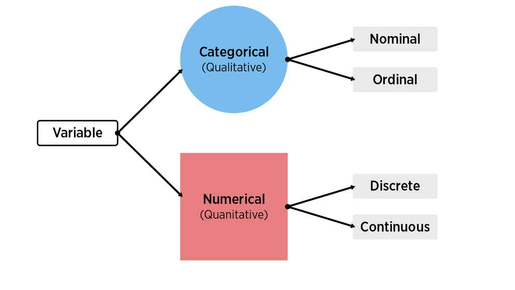

## Plotting

Three major systems for plotting:

- Base R (built-in functions)
  - Use `plot`, `barplot`, `hist`, etc. to start a plot
  - Annotate the plot using functions like `text`, `lines`, `points`, etc.
- Lattice (not covered)
- ggplot2 (sort of part of the tidyverse - Cheat Sheet)
  - `ggplot(data = data_frame)` creates a plot instance
  - Add “layers” to the system (geoms or stats)

Great [reference book here!](https://bookdown.org/rdpeng/exdata/plotting-systems.html)

## `ggplot2` Plotting

ggplot2 basics (Cheat Sheet)

- `ggplot(data = data_frame)` creates a plot instance
- Add “layers” to the system (geoms or stats)
  - Creates a visualization of the data

## `ggplot2` Plotting

ggplot2 basics (Cheat Sheet)

- `ggplot(data = data_frame)` creates a plot instance
- Add “layers” to the system (geoms or stats)
  - Creates a visualization of the data
- Modify layer “mapping” args (aes)
  - Ex: size, color, and x, y location(s)
- Coordinate system (mostly use Cartesian plane)
- Optional: Titles, etc.

## `factors`

- factor - special class of vector with a `levels` attribute
- Levels define all possible values for that variable
  - Great for variable like `Day` (Monday, Tuesday, …)
  - Not great for variable like `Name` where new values may come up
- Quite useful with plotting
  - Allows for easy labeling of subgroups

## `factors`

- Consider data on titanic passengers in `titanic.csv`

```r
titanicData <- read_csv("../datasets/titanic.csv")
#convert survival status to a factor
titanicData$survived <- as.factor(titanicData$survived)
levels(titanicData$survived) #R knows it isn't numeric now
```

```
## [1] "0" "1"
```

- Can’t add value unless it is a level

```r
titanicData$survived[1] <- "5"
```

## `factor` levels

```r
#overwrite with another possible level
levels(titanicData$survived) <- c(levels(titanicData$survived), "5")
levels(titanicData$survived)
```

```
## [1] "0" "1" "5"
```

```r
#no error
titanicData$survived[1] <- "5"
```

## `factor` levels

- Useful if you want to create better labels

```r
levels(titanicData$survived) <- c("Died", "Survived", "Other")
levels(titanicData$survived)
```

```
## [1] "Died"     "Survived" "Other"
```

## `factor` levels

- Useful if you want to create better labels

```r
levels(titanicData$survived) <- c("Died", "Survived", "Other")
levels(titanicData$survived)
```

```
## [1] "Died"     "Survived" "Other"
```

- Useful if you want to change order of values (say for plotting!)

```r
#or use ordered()
titanicData$survived <- factor(titanicData$survived,
                                  levels(titanicData$survived)[c(3, 2, 1)])
levels(titanicData$survived)
```

```
## [1] "Other"    "Survived" "Died"
```

## `ggplot2` Plotting: Categorical variables

Categorical variable - entries are a label or attribute

Goal: describe relative frequency (or count) in each category

- Generally, use a barplot!

## `ggplot2` barplots

- Barplots via `ggplot + geom_bar`
- Consider data on titanic passengers in `titanic.csv`

```r
titanicData <- read_csv("../datasets/titanic.csv")
titanicData$survived <- as.factor(titanicData$survived)
levels(titanicData$survived) <- c("Died", "Survived")
titanicData
```

```
## # A tibble: 1,310 x 14
##   pclass survived name  sex      age sibsp parch ticket  fare cabin embarked
##    <dbl> <fct>    <chr> <chr>  <dbl> <dbl> <dbl> <chr>  <dbl> <chr> <chr>
## 1      1 Survived Alle~ fema~ 29         0     0 24160   211. B5    S
## 2      1 Survived Alli~ male   0.917     1     2 113781  152. C22 ~ S
## 3      1 Died     Alli~ fema~  2         1     2 113781  152. C22 ~ S
## 4      1 Died     Alli~ male  30         1     2 113781  152. C22 ~ S
## 5      1 Died     Alli~ fema~ 25         1     2 113781  152. C22 ~ S
## # ... with 1,305 more rows, and 3 more variables: boat <chr>, body <dbl>,
## #   home.dest <chr>
```

## `ggplot2` barplots

- Barplots via `ggplot + geom_bar`
- Across x-axis we want our categories - specify with `aes(x = ...)`

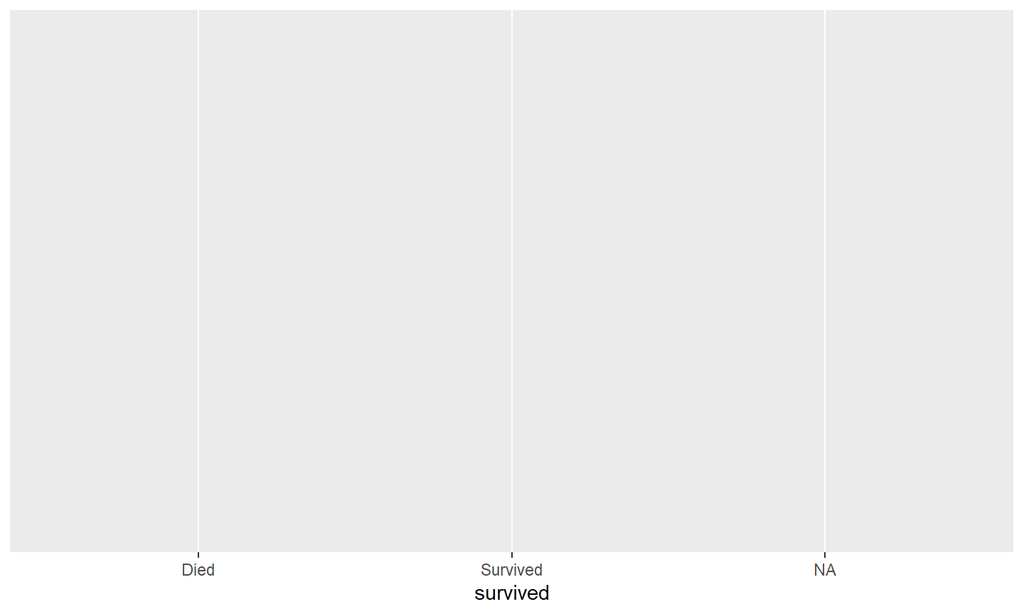

```r
ggplot(data = titanicData, aes(x = survived))
```

## `ggplot2` barplots

- Barplots via `ggplot + geom_bar`
- Must add geom (or stat) layer!

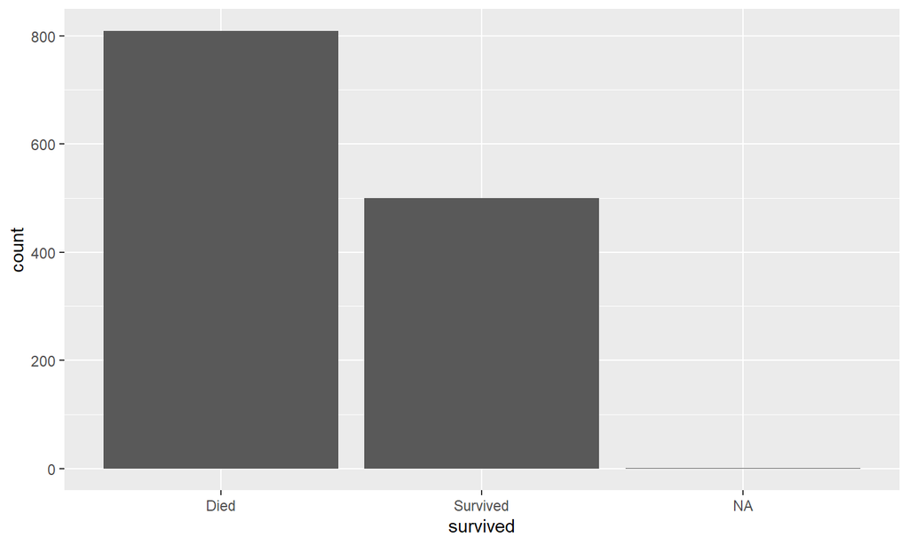

```r
ggplot(data = titanicData, aes(x = survived)) + geom_bar()
```

## `ggplot2` barplots

- Generally: Save base object, then “add layers”

```r
g <- ggplot(data = titanicData, aes(x = survived))
g + geom_bar()
```

## `ggplot2` barplots

- Generally: Save base object, then “add layers”

```r
g <- ggplot(data = titanicData, aes(x = survived))
g + geom_bar()
```

- `aes()` defines visual properties of objects in the plot

`x = , y = , size = , shape = , color = , alpha = , ...`

- Cheat Sheet gives most common properties for a given `geom`

## `ggplot2` barplots

- Generally: Save base object, then “add layers”

```r
g <- ggplot(data = titanicData, aes(x = survived))
g + geom_bar()
```

- `aes()` defines visual properties of objects in the plot

`x = , y = , size = , shape = , color = , alpha = , ...`

- Cheat Sheet gives most common properties for a given `geom`

`d + geom_bar()`

`x, alpha, color, fill, linetype, size, weight`

## `ggplot2` global and local aesthetics

`data` and `aes` can be set in two ways;

- ‘globally’ (for all layers) via the `ggplot` statement
- ‘locally’ (for just that layer) via the `geom`, `stat`, etc. layer

## `ggplot2` global and local aesthetics

`data` and `aes` can be set in two ways;

- ‘globally’ (for all layers) via the `ggplot` statement
- ‘locally’ (for just that layer) via the `geom`, `stat`, etc. layer

```r
#global
ggplot(data = titanicData, aes(x = survived)) + geom_bar()
#local
ggplot() + geom_bar(data = titanicData, aes(x = survived))
```

## `ggplot2` global and local aesthetics

`data` and `aes` can be set in two ways;

- ‘globally’ (for all layers) via the `ggplot` statement
- ‘locally’ (for just that layer) via the `geom`, `stat`, etc. layer

```r
#global
ggplot(data = titanicData, aes(x = survived)) + geom_bar()
#local
ggplot() + geom_bar(data = titanicData, aes(x = survived))
```

- To set an attribute that doesn’t depend on the data (i.e. `color = 'blue'`), generally place these outside of the `aes`

## `ggplot2` barplots

- Improve plot by removing `NA` category

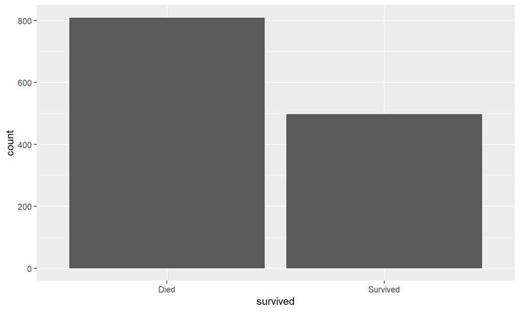

```r
titanicData <- titanicData %>% drop_na(survived, sex, embarked)
g <- ggplot(data = titanicData, aes(x = survived))
g + geom_bar()
```

## `ggplot2` barplots

- Add better labels and a title (new layers, see cheat sheet!)

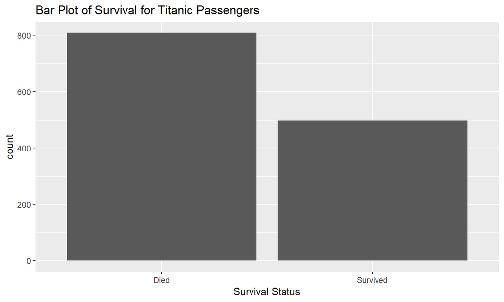

```r
ggplot(data = titanicData, aes(x = as.character(survived))) +
  geom_bar() +
  labs(x = "Survival Status", title = "Bar Plot of Survival for Titanic Passengers")
```

## `ggplot2` stacked barplots

- **Stacked barplot** created by via `fill` aesthetic and same process
  - Create base object
  - Add geoms
  - Use aes to specify aspects of the plot

## `ggplot2` stacked barplots

- **Stacked barplot** created by via `fill` aesthetic
- Automatic assignment of colors, creation of legends, etc. for `aes` elements (except with `group`)

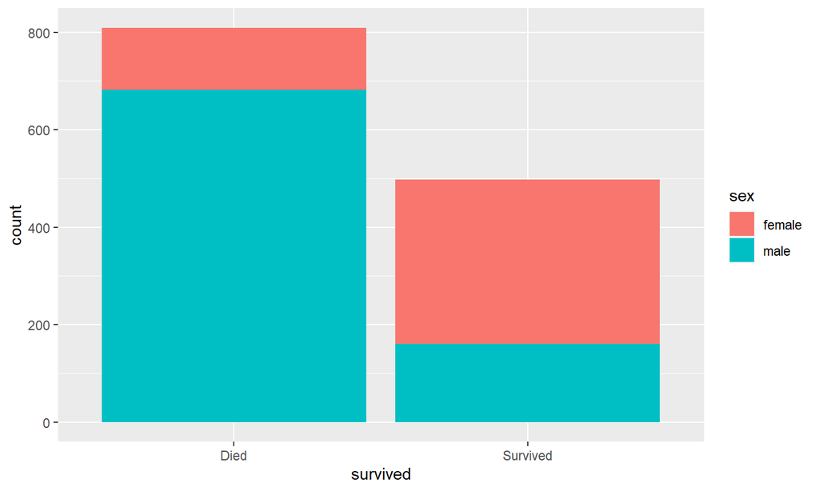

```r
ggplot(data = titanicData, aes(x = survived, fill = sex)) + geom_bar()
```

## `ggplot2` labeling

- Add custom labels by adding more layers

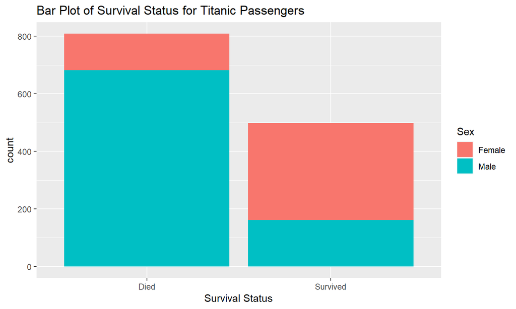

```r
ggplot(data = titanicData, aes(x = survived, fill = sex)) +
  geom_bar() +
  labs(x = "Survival Status",
       title = "Bar Plot of Survival Status for Titanic Passengers") +
  scale_fill_discrete(name = "Sex", labels = c("Female", "Male"))
```

## `ggplot2` labeling

- Adjusting appropriate labeling via `scale_*_discrete`

`aes(x = survived, fill = sex)`

`scale_x_discrete(labels = c("Person Died", "Person Survived"))`

`scale_fill_discrete(name = "Sex", labels = c("Female","Male"))`